# Cultural Equity in R

Dr Pete McKenna

2024-10-02

# Rationale

- WEIRD datasets more commonly available and do not enhance R teaching equity
- Use of non-WERID datasets may serve to promote feelings of belonging and inclusivity in diverse student samples
- Students implicitly learn about the challenges of dataset retrieval and the importance of good metadata

# Data

- I have found data from ‘Global Gender Gap Report 2024’ for Sub-Saharan Africa
- The goal is to read and interpret this data in R
- The data contains a iso3 code vector, so I’ve also found a related dataset to provide country name data.

# Load packages

These will need to be installed using the console if not already installed.

```r
# Load the tidyverse
library(tidyverse)
library(psych)
library(skimr)
```

# Read in the data

```r
# Read in the GGGI data
  # either copy and paste the URL from a website or download and read in as you would other files.
df <-
  read_csv("https://open.africa/dataset/36993281-baa5-490d-b6ff-d4750a09d2bb/resource/e7fd9a05-89e2-459a-98ca-e1b40f9a2b1a/download/sub-saharan-africa-ggi-ranks-and-scores.csv",
           skip = 1)  # as the first row is empty (from inspection) skip this

# Read in the iso3 code data
iso <-
  read_csv("https://raw.githubusercontent.com/lukes/ISO-3166-Countries-with-Regional-Codes/refs/heads/master/all/all.csv") |>
  select(1,    # Country name
         3)    # iso3 code
```

# Examine the datasets

```r
# Check the first and last observations
headTail(df)
```

```
##   country_iso3  global_id edition index attribute value             Region
## 1          TCD gggi_index    2024  GGGI     score  0.58 Sub-Saharan Africa
## 2          TCD gggi_index    2024  GGGI      rank   144 Sub-Saharan Africa
## 3          GIN gggi_index    2024  GGGI     score   0.6 Sub-Saharan Africa
## 4          GIN gggi_index    2024  GGGI      rank   142 Sub-Saharan Africa
## 5         <NA>       <NA>     ...  <NA>      <NA>   ...               <NA>
## 6          RWA gggi_index    2023  GGGI     score  0.79 Sub-Saharan Africa
## 7          RWA gggi_index    2023  GGGI      rank    12 Sub-Saharan Africa
## 8          NAM gggi_index    2023  GGGI     score   0.8 Sub-Saharan Africa
## 9          NAM gggi_index    2023  GGGI      rank     8 Sub-Saharan Africa
```

```r
headTail(iso)
```

```
##             name alpha.3
## 1    Afghanistan     AFG
## 2  Åland Islands     ALA
## 3        Albania     ALB
## 4        Algeria     DZA
## 5           <NA>    <NA>
## 6 Western Sahara     ESH
## 7          Yemen     YEM
## 8         Zambia     ZMB
## 9       Zimbabwe     ZWE
```

```r
# Check the structure of the data
glimpse(df)
```

```
## Rows: 1,080
## Columns: 7
## $ country_iso3 <chr> "TCD", "TCD", "GIN", "GIN", "MLI", "MLI", "COD", "COD", "…
## $ global_id    <chr> "gggi_index", "gggi_index", "gggi_index", "gggi_index", "…
## $ edition      <dbl> 2024, 2024, 2024, 2024, 2024, 2024, 2024, 2024, 2024, 202…
## $ index        <chr> "GGGI", "GGGI", "GGGI", "GGGI", "GGGI", "GGGI", "GGGI", "…
## $ attribute    <chr> "score", "rank", "score", "rank", "score", "rank", "score…
## $ value        <dbl> 0.5760569, 144.0000000, 0.6010881, 142.0000000, 0.6040917…
## $ Region       <chr> "Sub-Saharan Africa", "Sub-Saharan Africa", "Sub-Saharan …
```

```r
glimpse(iso)
```

```
## Rows: 249
## Columns: 2
## $ name      <chr> "Afghanistan", "Åland Islands", "Albania", "Algeria", "Ameri…
## $ `alpha-3` <chr> "AFG", "ALA", "ALB", "DZA", "ASM", "AND", "AGO", "AIA", "ATA…
```

# Special date case

Information contained in the vector `edition` relates to specific years, but these do not contain the necessary info to be converted in a date type vector (e.g., “YYYY-MM-DD”). So, we can leave it as it is.

# International Organization for Standardization (ISO) labels

You can see that this information is contained in both datasets, but they are labelled differently. The GGGI data labels it `country_iso3`, whereas the iso index labels it `alpha-3`.

We will need to join these data in order to add the country names to the GGGI data. This is possible using R’s join functions.

# Join iso information to get country name

```r
# Rename alpha-3
iso <-
  iso |>
  rename(country_iso3 = `alpha-3`)

# Join the datasets
df1 <-
  left_join(df, iso,
            by = "country_iso3") |>
  select(8,1,7,2:6) # re-arrange the vectors to tidy up

# Examine the data
glimpse(df1)
```

```
## Rows: 1,080
## Columns: 8
## $ name         <chr> "Chad", "Chad", "Guinea", "Guinea", "Mali", "Mali", "Cong…
## $ country_iso3 <chr> "TCD", "TCD", "GIN", "GIN", "MLI", "MLI", "COD", "COD", "…
## $ Region       <chr> "Sub-Saharan Africa", "Sub-Saharan Africa", "Sub-Saharan …
## $ global_id    <chr> "gggi_index", "gggi_index", "gggi_index", "gggi_index", "…
## $ edition      <dbl> 2024, 2024, 2024, 2024, 2024, 2024, 2024, 2024, 2024, 202…
## $ index        <chr> "GGGI", "GGGI", "GGGI", "GGGI", "GGGI", "GGGI", "GGGI", "…
## $ attribute    <chr> "score", "rank", "score", "rank", "score", "rank", "score…
## $ value        <dbl> 0.5760569, 144.0000000, 0.6010881, 142.0000000, 0.6040917…
```

We now have names instead of codes only for countries in the dataset.

# Rehape the data

It might actually be useful to split `attribute` into separate ranks and scores. We can do this using the `pivot_wider` function.

```r
# Widen the data by separating attribute
df1 <-
  df1 |>
  pivot_wider(names_from = "attribute",
              values_from = "value")

# Check it worked
head(df1)
```

```
## # A tibble: 6 × 8
##   name                   country_iso3 Region global_id edition index score  rank
##   <chr>                  <chr>        <chr>  <chr>       <dbl> <chr> <dbl> <dbl>
## 1 Chad                   TCD          Sub-S… gggi_ind…    2024 GGGI  0.576   144
## 2 Guinea                 GIN          Sub-S… gggi_ind…    2024 GGGI  0.601   142
## 3 Mali                   MLI          Sub-S… gggi_ind…    2024 GGGI  0.604   141
## 4 Congo, Democratic Rep… COD          Sub-S… gggi_ind…    2024 GGGI  0.609   140
## 5 Niger                  NER          Sub-S… gggi_ind…    2024 GGGI  0.628   138
## 6 Benin                  BEN          Sub-S… gggi_ind…    2024 GGGI  0.629   134
```

# Are there any missing values?

Use the `skimr` package function `skim` to generate a report about missing values.

```r
skim(df1)
```

[output not shown]

# Omit missing values

```r
# Use drop_na function to omit rows with missing values
df1 <-
  df1 |>
  drop_na()
```

With the NAs omitted, we can plot the rank data using ggplot2. Before we do, let’s take a look at our vectors again, so we know roughly what our plot hsould look like.

# Data parameters

We want to know, for example, how many observations were recorded per year represented, how many countries, and what the max and min are for rank. This information will help us identify if something has gone wrong.

```r
# How many years?
df1 |>
  group_by(edition) |>
  count()
```

```
## # A tibble: 18 × 2
## # Groups:   edition [18]
##    edition     n
##      <dbl> <int>
##  1    2006    23
##  2    2007    24
##  3    2008    24
##  4    2009    25
##  5    2010    26
##  6    2011    27
##  7    2012    26
##  8    2013    26
##  9    2014    29
## 10    2015    32
## 11    2016    31
## 12    2017    31
## 13    2018    34
## 14    2019    35
## 15    2021    36
## 16    2022    36
## 17    2023    36
## 18    2024    35
```

We can see that the years 2006 to 2024 are included. The number of observations per year (i.e., numbers of countries data) varies too.

```r
# How many countries?
df1 |>
  select(name) |>
  count()
```

```
## # A tibble: 1 × 1
##       n
##   <int>
## 1   536
```

```r
# Min and max for rank
df1 |>
  summarise(max_rank = max(rank),
            min_rank = min(rank))
```

```
## # A tibble: 1 × 2
##   max_rank min_rank
##      <dbl>    <dbl>
## 1      151        4
```

The Max is 151 and the min is 4.

# Plot the data

# Which countries have data for every year in the dataset?

```r
# By counting the number of times a name occurs we count the number of years as these are uniqe per row
df1 |>
  count(name) |>
  filter(n ==18) # country will need 18 data points to have a full set (i.e., from 2006-2024)
```

```
## # A tibble: 15 × 2
##    name                             n
##    <chr>                        <int>
##  1 Botswana                        18
##  2 Burkina Faso                    18
##  3 Chad                            18
##  4 Ethiopia                        18
##  5 Ghana                           18
##  6 Kenya                           18
##  7 Lesotho                         18
##  8 Madagascar                      18
##  9 Mali                            18
## 10 Mauritius                       18
## 11 Namibia                         18
## 12 Nigeria                         18
## 13 South Africa                    18
## 14 Tanzania, United Republic of    18
## 15 Uganda                          18
```

So, from this list let’s pick 5: “Botswana”, “Chad”, “Kenya”, “Nigeria” and “Uganda”

```r
# Pluck a sample of countries
df2 <-
  df1 |>
  rename(year = edition) |> # change this to year for clarity
  filter(name %in% c("Botswana",
                     "Chad",
                     "Kenya",
                     "Nigeria",
                     "Uganda"))

# Check the countries included in the data
unique(df2$name)
```

```
## [1] "Chad"     "Nigeria"  "Kenya"    "Botswana" "Uganda"
```

## Plot the data using a line plot

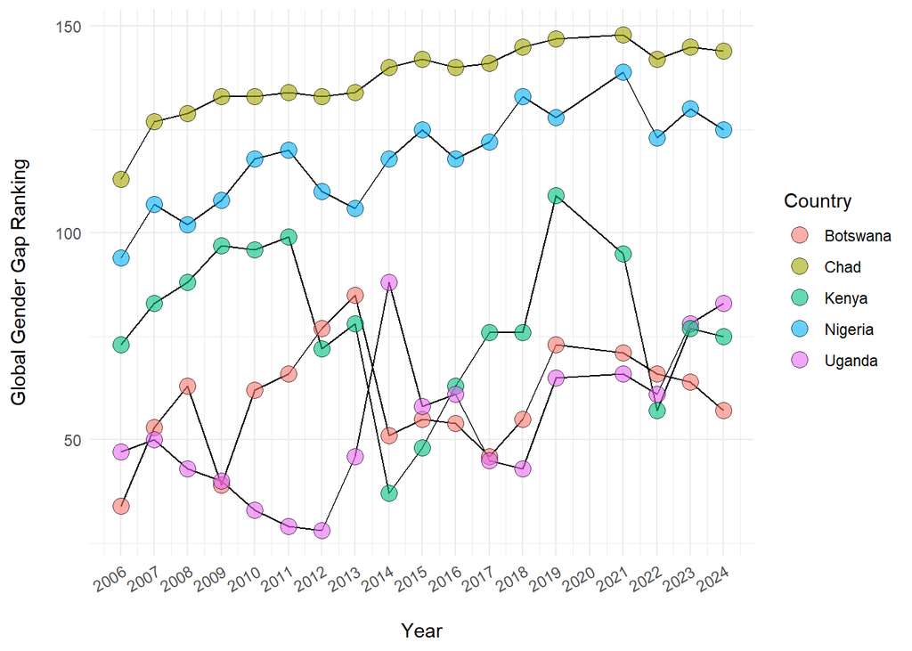

```r
# Create a vector for years included in the data
years_incl <-
  seq(2006, 2024, by = 1) # a sequence start with 2006 to 2024, in increments of 1

# Plot the data as a line plot with points
ggplot(df2,
       aes(x = year,
           y = rank,
           fill = name)) +
  geom_line() +
  geom_point(size = 4,
             shape = 21,
             alpha = 0.6) +
  labs(x = "\nYear",
       y = "Global Gender Gap Ranking\n",
       fill = "Country") +
  scale_x_continuous(breaks = years_incl) +
  theme_minimal() +
  theme(axis.text.x = element_text(angle = 30, hjust = 1, vjust = 1))
```

# Summary and conclusions

- Today I’ve shown you how to read data from the web and to tidy and visualise it in R.
- It is important to note that I selected this data because it was non-Western, and the source provided some metadata for me to make sense of it - it’s really hard to work with data that you know nothing about!
- As you have learned, programming in R can be challenging and requires you to think carefully about the structure of data.
- However, the pay-off is amazing and worth it in the long run.